# Análise dos gastos da câmara dos deputados

Bruno Rafael Araújo Vasconcelos

31 de março de 2017

Para esta pesquisa, avaliamos apenas os gastos com as cotas dos deputados da região nordeste do Brasil. Utilizamos os dados dos gastos da câmara dos deputados desde o mês de janeiro do ano de 2015 até o mês atual(março) e podem ser em contrados em http://www2.camara.leg.br/transparencia/cota-para-exercicio-da-atividade-parlamentar/dados-abertos-cota-parlamentar.

### O que queremos saber?

Procuramos responder nesta análise a duas perguntas:

**1. Quais as despesas em que os deputados mais gastam sua cota?**

**2. Que tipos de despesa tem valores que mais variam quando comparamos os deputados?**

### Quais tratamentos foram feitos nos dados?

Os dados do portal da camara apresentaram algumas inconsistências. Procuramos tratar os dados e sanar os problemas da melhor forma possível .

[output not shown]

# Análise

Desde 2014, cada deputado em seu exercício parlamentar custou até o mês de março de 2017 um valor variável para os cofres públicos. Alguns deputados custaram mais de 1 milhão de reais, enquanto que outros não chegaram aos 100 mil.

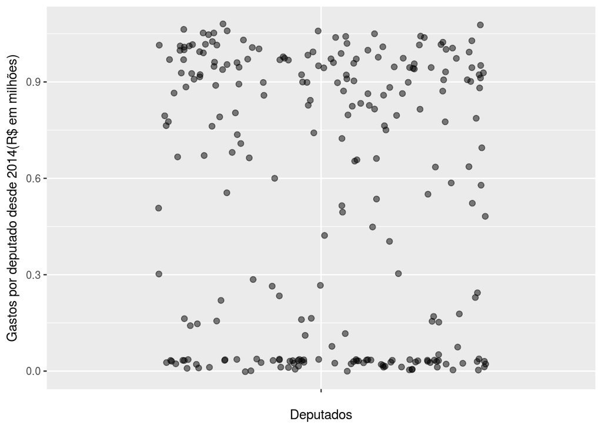

Cada deputado, desde 2014, gastou mais em alguma coisa. Por exemplo, o deputado Romulo Gouveia da paraíba gastou mais com Passagens aéreas (aproximadatamente 170 mil reais) enquanto que Aguinaldo Ribeiro também da Paraíba gastou com Divulgação da atividade parlamentar.

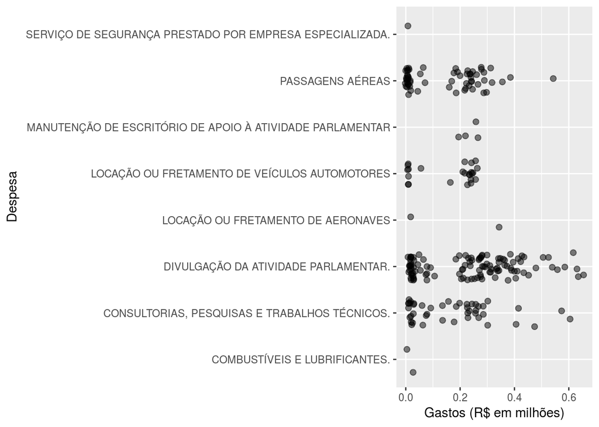

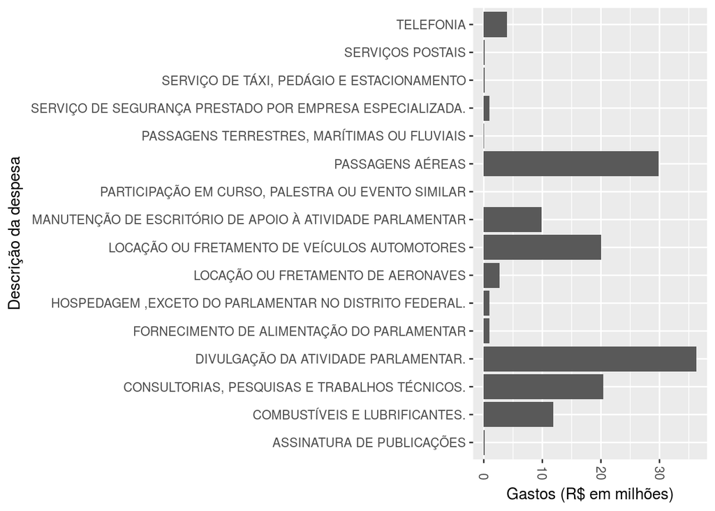

Esses resultados não se tratam de casos isolados que fizeram que a soma dos resultados aumentasse gradativamente os gastos com esse tipo de despesa. Anualmente os parlamentares gastam de forma semelhante suas cotas com divulgação de suas atividades de modo que a proporção ao longo dos anos é semelhante.

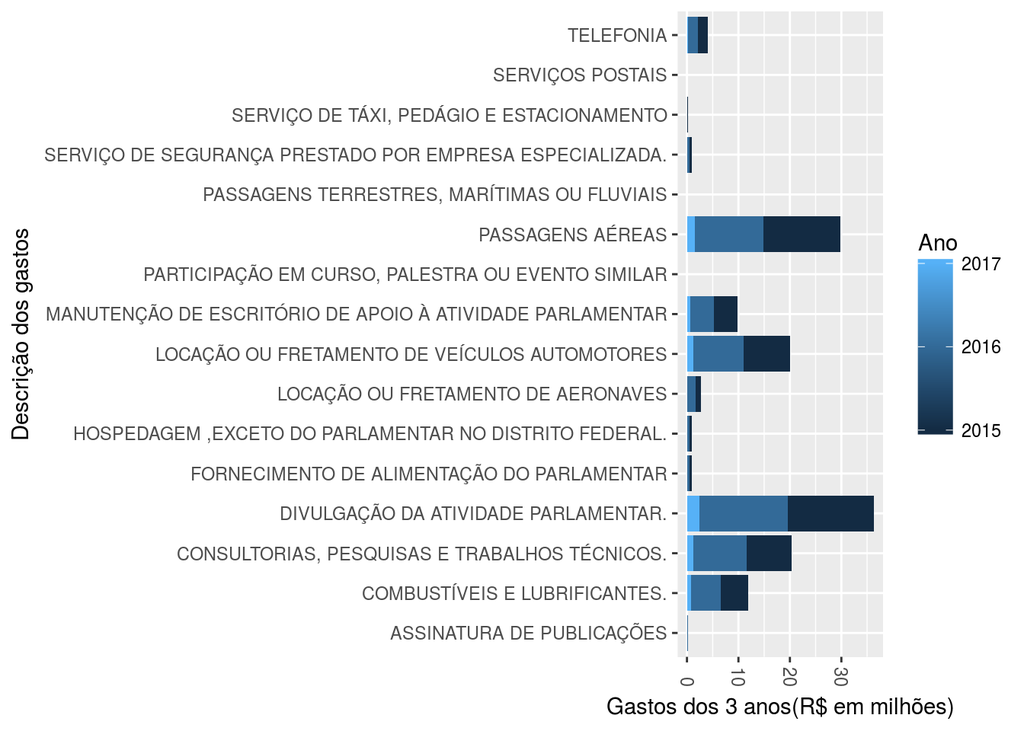

# Avaliando as distribuições de cada tipo de gasto

Os depuados gastam de forma diferente um dos outros com valores que variam de “muitos gastos” para “poucos gastos”.

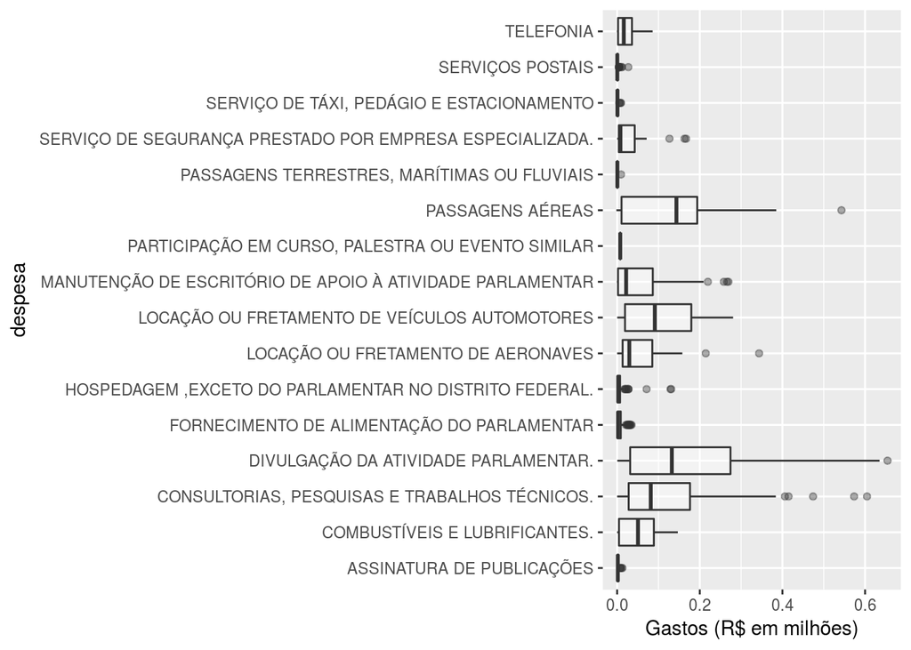

O tipo de despesa que mais varia, novamente é “Divulgação da atividade parlamentar”. Isso é curioso, pois esta é a despesa em que mais os deputados gastam suas cotas enquanto que a despesa “Assinatura de publicações”, para todos os deputados que gastam com isso, eles gastam de forma “semelhante”, a diferença de valores gastos por cada deputado é bem menor do que em outras variáveis como “Divulgação da atividade parlamentar”, “Passagens aéreas” e “Locação ou fretamento de veículos automotores”. Isso ocorre ao longo dos 3 anos.

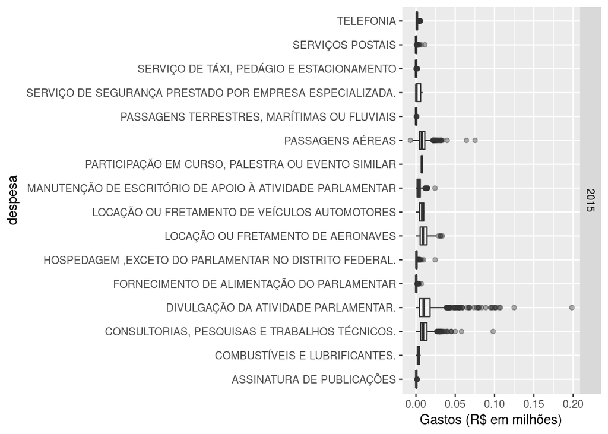

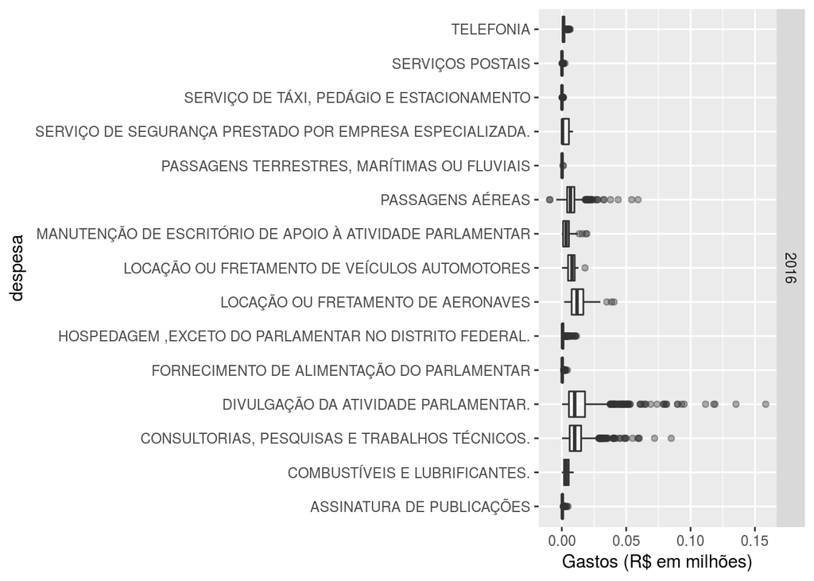

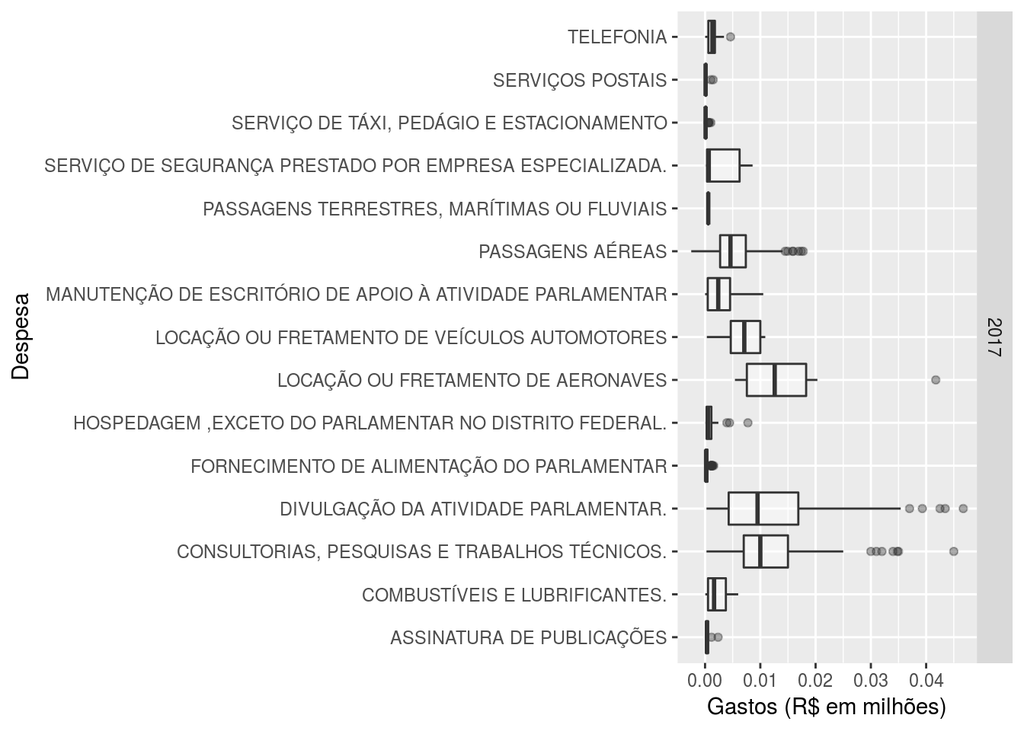

Perceba que “Divulgação da atividade parlamentar” continua sendo a “campeã”, os gráficos para esta despesa continuam mais “esticados” do que os outros.

Para terminar nossa análise, vamos observar algumas métricas estatísticas e comparar com nossos gráficos.

Vamos olhar especificamente para as “6 primeiras” despesas que apresentaram um “esticamento” maior nos gráficos.

| txtDescricao | Total | IQR | Desvio_padrao |
| --- | --- | --- | --- |
| LOCAÇÃO OU FRETAMENTO DE AERONAVES | 2675745.0 | 6595.00 | 4927.083 |
| DIVULGAÇÃO DA ATIVIDADE PARLAMENTAR. | 36330701.7 | 5500.00 | 8247.965 |
| CONSULTORIAS, PESQUISAS E TRABALHOS TÉCNICOS. | 20372639.0 | 5500.00 | 6496.309 |
| SERVIÇO DE SEGURANÇA PRESTADO POR EMPRESA ESPECIALIZADA. | 945439.7 | 4589.77 | 3050.865 |
| LOCAÇÃO OU FRETAMENTO DE VEÍCULOS AUTOMOTORES | 20024464.4 | 3687.50 | 2700.393 |
| MANUTENÇÃO DE ESCRITÓRIO DE APOIO À ATIVIDADE PARLAMENTAR | 9855744.2 | 964.57 | 1424.318 |

Aqui, a despesa “campeã” não foi “Divulgação da atividade parlamentar” e sim “Locação ou fretamento de aeronaves”, porém ambas estão nas primeiras posições. Observe que quanto maior o IQR mais o gráfico é esticado e consequentemente mais discrepante são os gastos por deputado.

## Conclusão

Para a primeira pergunta, há indícios de que o tipo de despesa na qual os deputados nordestinos mais gastam é em **Divulgação da atividade parlamentar** considerando os últimos três anos. E este mesmo tipo de despesa é um tipo de despesa que varia muito os totais gastos de deputado para deputado, assim como **Locação ou fretamento de aeronaves** e **consultorias pesquisas e trabalhos técnicos** respondendo a segunda pergunta.